# Epidemiological Analysis of Cardiovascular Risk Factors

Rishabh Jha

2026-06-19

# Introduction

Cardiovascular disease is one of the leading causes of morbidity and mortality worldwide. This project uses the NHANES dataset to investigate relationships between age, body mass index (BMI), smoking status, physical activity, diabetes, and blood pressure.

The goals of this analysis were to:

- Classify participants using WHO BMI categories.
- Classify participants using AHA hypertension guidelines.
- Explore relationships between cardiovascular risk factors and blood pressure.
- Apply statistical techniques commonly used in epidemiological research.

```r
library(tidyverse)
library(NHANES)
```

# Data Preparation

The NHANES dataset was filtered to include adults aged 20 years and older. Participants with missing blood pressure measurements were excluded. Duplicate participant IDs were removed to ensure that each observation represented a unique individual.

```r
adults <- NHANES %>%
  filter(Age >= 20)

adults_bp <- adults %>%
  filter(
    !is.na(BPSysAve),
    !is.na(BPDiaAve)
  )

adults_bp <- adults_bp %>%
  mutate(
    BMI_Class = case_when(
      BMI < 18.5 ~ "Underweight",
      BMI < 25 ~ "Normal",
      BMI < 30 ~ "Overweight",
      BMI >= 30 ~ "Obese",
      TRUE ~ NA_character_
    )
  )

adults_bp <- adults_bp %>%
  mutate(
    BMI_Class = factor(
      BMI_Class,
      levels = c(
        "Underweight",
        "Normal",
        "Overweight",
        "Obese"
      )
    )
  )

adults_bp <- adults_bp %>%
  mutate(
    HTN_Stage = case_when(
      BPSysAve < 120 & BPDiaAve < 80 ~ "Normal",
      BPSysAve >= 120 &
        BPSysAve < 130 &
        BPDiaAve < 80 ~ "Elevated",
      (BPSysAve >= 130 & BPSysAve < 140) |
        (BPDiaAve >= 80 & BPDiaAve < 90) ~ "Stage 1",
      BPSysAve >= 140 |
        BPDiaAve >= 90 ~ "Stage 2",
      TRUE ~ NA_character_
    )
  )

adults_bp <- adults_bp %>%
  filter(!is.na(BMI))

adults_bp_unique <- adults_bp %>%
  distinct(ID, .keep_all = TRUE)

nrow(adults_bp_unique)
```

```
## [1] 4424
```

After filtering to adult participants, removing missing blood pressure measurements, and retaining only one observation per participant, the final analytical dataset contained 4,424 unique adults.

Participants were classified according to World Health Organization (WHO) BMI categories and American Heart Association (AHA) hypertension guidelines.

# Results

## Figure 1: Hypertension Stage by BMI Category

The first analysis examined whether hypertension prevalence differed across BMI categories.

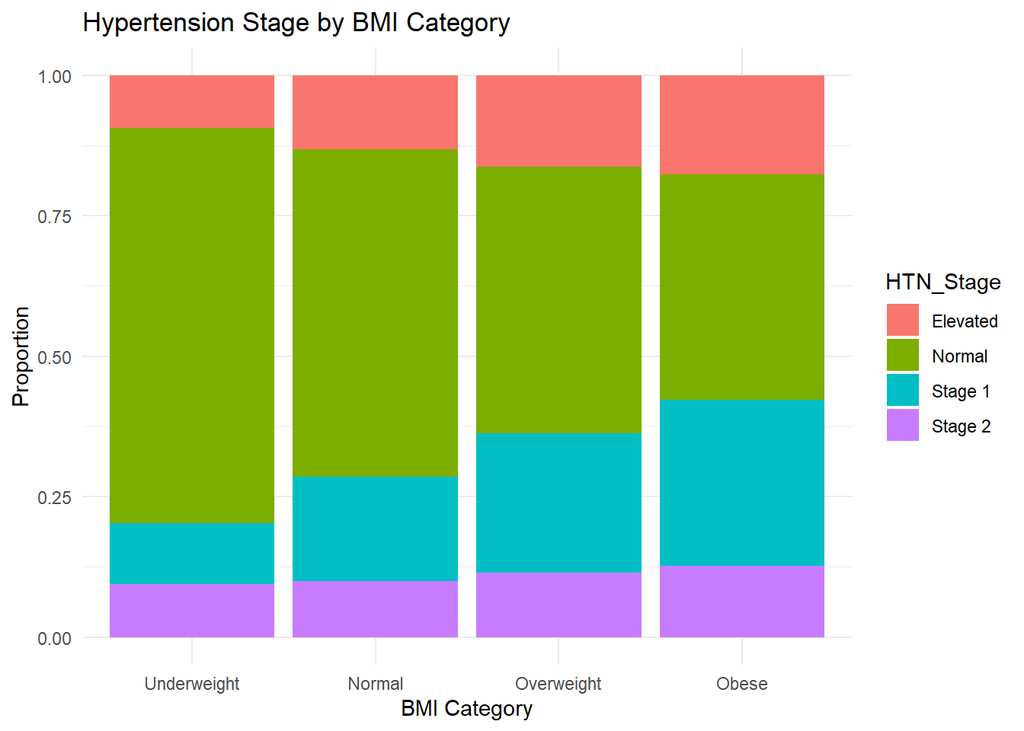

```r
ggplot(
  adults_bp_unique,
  aes(
    x = BMI_Class,
    fill = HTN_Stage
  )
) +
  geom_bar(position = "fill") +
  labs(
    title = "Hypertension Stage by BMI Category",
    x = "BMI Category",
    y = "Proportion"
  ) +
  theme_minimal()
```

The proportion of Stage 1 and Stage 2 hypertension increased as BMI category increased. Obese participants exhibited a substantially lower proportion of normal blood pressure compared with normal-weight participants.

## Figure 2: Age and Systolic Blood Pressure

The relationship between age and systolic blood pressure was examined using a scatter plot with a fitted linear regression line.

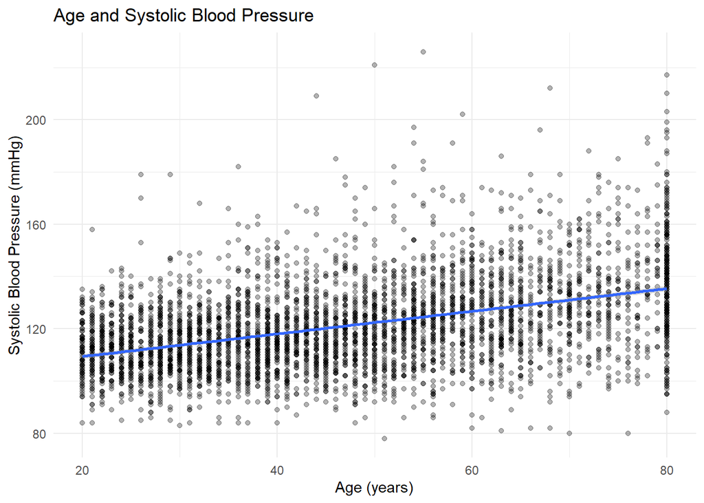

```r
ggplot(
  adults_bp_unique,
  aes(
    x = Age,
    y = BPSysAve
  )
) +
  geom_point(alpha = 0.3) +
  geom_smooth(method = "lm") +
  labs(
    title = "Age and Systolic Blood Pressure",
    x = "Age (years)",
    y = "Systolic Blood Pressure (mmHg)"
  ) +
  theme_minimal()
```

A positive relationship was observed between age and systolic blood pressure. Older participants generally exhibited higher blood pressure values, although considerable variability remained within each age group.

## Figure 3: Age and Blood Pressure by Smoking Status

Smoking status was examined as a potential modifier of the relationship between age and systolic blood pressure.

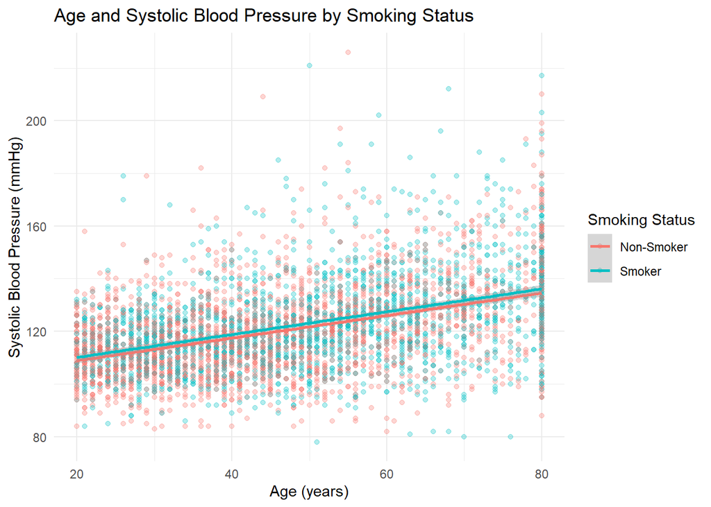

```r
ggplot(
  adults_bp_unique,
  aes(
    x = Age,
    y = BPSysAve,
    color = Smoke100n
  )
) +
  geom_point(alpha = 0.3) +
  geom_smooth(method = "lm") +
  labs(
    title = "Age and Systolic Blood Pressure by Smoking Status",
    x = "Age (years)",
    y = "Systolic Blood Pressure (mmHg)",
    color = "Smoking Status"
  ) +
  theme_minimal()
```

The positive association between age and systolic blood pressure was evident among both smokers and non-smokers.

# Statistical Analysis

## Cholesterol Comparison Between Smokers and Non-Smokers

A Welch two-sample t-test was used to compare mean total cholesterol levels between smokers and non-smokers.

```r
chol_data <- adults_bp_unique %>%
  filter(
    !is.na(TotChol),
    !is.na(Smoke100n)
  )

t.test(
  TotChol ~ Smoke100n,
  data = chol_data
)
```

```
##
##  Welch Two Sample t-test
##
## data:  TotChol by Smoke100n
## t = 0.10388, df = 3884.5, p-value = 0.9173
## alternative hypothesis: true difference in means between group Non-Smoker and group Smoker is not equal to 0
## 95 percent confidence interval:
##  -0.06158454  0.06847559
## sample estimates:
## mean in group Non-Smoker     mean in group Smoker
##                 5.054615                 5.051170
```

No statistically significant difference in mean cholesterol levels was observed between smokers and non-smokers (p = 0.917).

## Multiple Linear Regression

A multiple linear regression model was fitted to evaluate whether age and BMI predicted systolic blood pressure.

```r
bp_model <- lm(
  BPSysAve ~ Age + BMI,
  data = adults_bp_unique
)

summary(bp_model)
```

```
##
## Call:
## lm(formula = BPSysAve ~ Age + BMI, data = adults_bp_unique)
##
## Residuals:
##     Min      1Q  Median      3Q     Max
## -54.300  -9.751  -1.109   8.275 101.000
##
## Coefficients:
##             Estimate Std. Error t value Pr(>|t|)
## (Intercept) 93.88531    1.19074  78.846  < 2e-16 ***
## Age          0.42908    0.01358  31.606  < 2e-16 ***
## BMI          0.24275    0.03460   7.016 2.64e-12 ***
## ---
## Signif. codes:  0 '***' 0.001 '**' 0.01 '*' 0.05 '.' 0.1 ' ' 1
##
## Residual standard error: 15.7 on 4421 degrees of freedom
## Multiple R-squared:  0.1946, Adjusted R-squared:  0.1943
## F-statistic: 534.2 on 2 and 4421 DF,  p-value: < 2.2e-16
```

Age and BMI were both positively associated with systolic blood pressure. The model explained approximately 19% of the variation in blood pressure measurements.

# Discussion

This analysis examined cardiovascular risk factors using data from the NHANES survey. Participants were classified according to WHO BMI categories and AHA hypertension guidelines to explore relationships between demographic and health-related variables.

Age and BMI were both positively associated with systolic blood pressure. The prevalence of Stage 1 and Stage 2 hypertension increased across BMI categories, suggesting a relationship between body weight and cardiovascular risk.

Several limitations should be noted. NHANES is an observational dataset, meaning causal relationships cannot be established. Additionally, some potentially relevant variables were unavailable or contained missing data.

Overall, this project demonstrates a reproducible epidemiological analysis workflow using R, including data cleaning, visualization, statistical testing, and regression modeling.

# Conclusion

Using data from 4,424 unique adult participants in the NHANES dataset, this project explored relationships between demographic and lifestyle factors and cardiovascular health outcomes.

The analysis found that both age and BMI were positively associated with systolic blood pressure. Additionally, the prevalence of hypertension increased across BMI categories, highlighting the relationship between body weight and cardiovascular risk.

This project demonstrates the use of R for reproducible epidemiological analysis, including data cleaning, visualization, hypothesis testing, and statistical modeling. The workflow provides a foundation for future health data science and clinical research projects.